# Git, GitHub & Ocean Acidification

# **Task 6**

This task involves teaming up with a collaborator. Exchange *GitHub* username details and add each other to your repo. Clone each others’ repo on to your computer. Re-run their code. Does it work? If not, correct it for them. Explain to them WHY it didn’t work. After all, they are right beside you! Think carefully about this. Will it still run on their computer if you have corrected it in a certain way?

Now, lets create a new figure in the code block below that simplifies the one produced in **Task 5**. Instead of all species, lets just plot three of the species (chromis, lemon, and acantho). In the figure code chunk make sure you add the necessary arguments (e.g., `fig.cap`) so that you can refer to Figure 2.

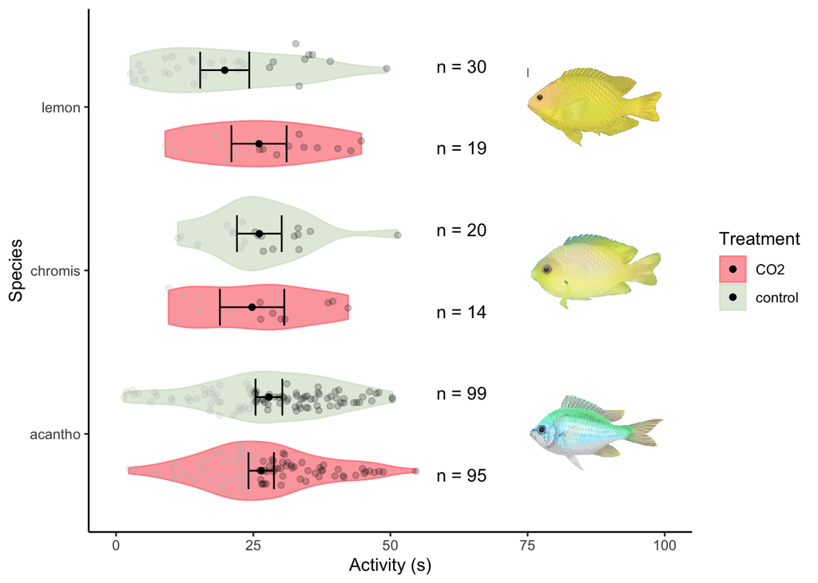

Figure 2: Revised figure from collaborator

```r
# You want to make changes to your collaborators figure in Task 5. Maybe you want to create a figure that focuses only on three fish species instead of the 5. More specifically, chromis, lemon, and acantho. Add code here to revise their figure to do that.

# First lets just sub-sample data and summary table
data_clean_sub   <- data_clean %>% filter(species %in% c("chromis", "lemon","acantho"))
summary_data_sub <- summary_data %>% filter(Species %in% c("chromis", "lemon","acantho"))

p2 <- ggplot(data_clean_sub, aes(x =species, y = activity)) +
  geom_violin(aes(fill = treatment, col = treatment), alpha = 0.8) +
  geom_sina(data = . %>% filter(activity >= 25), aes(fill = treatment, col = treatment), colour = "black", alpha=0.2) + # Here's a COOL feature. You can wrangle data directly from data frame to highly something neat, like activities all above and below 25. The '.' is meant to represent the tibble data frame and just like we would manipulate there we can do the same here.
  geom_sina(data = . %>% filter(activity <= 25), aes(fill = treatment, col = treatment), colour = "gray", alpha=0.2) +
  labs(x = "Species", y = "Activity (s)", fill = "Treatment", col = "Treatment") +
  ylim(0, 100) +  # Make axes large as we may want to add in pictures of the species
  geom_errorbar(data = summary_data_sub %>% filter(Species %in% c("chromis", "lemon","acantho")), aes(x = Species, y = `Mean Activity`, ymin = `Mean Activity`+2*`Standard Error`, ymax = `Mean Activity`-2*`Standard Error`), position=position_dodge2(width = 0.01, padding = 0.5), size = 0.5) +   # We've already created the means and se data so we can feed this new tibble in
  geom_point(data = summary_data_sub, aes(x = Species, y = `Mean Activity`, fill = Treatment, col = Treatment), position = position_dodge(width = 0.9), colour = "black") +
  theme_classic() +
  annotate("text", x = c(0.75, 1.25, 1.75, 2.25, 2.75, 3.25), y = 63, label = paste0("n = ", summary_data_sub$N)) +
  scale_fill_manual(breaks = c("CO2", "control"),
                    values=c("#fc9197", "#dde6d5")) +
  scale_color_manual(breaks = c("CO2", "control"),
                  values=c("#fc9197", "#dde6d5")) +
  coord_flip() +
  annotation_raster(chromas, xmin = 1.75, xmax = 2.25, ymin = 75, ymax = 100) +
  annotation_raster(lemon, xmin =2.75, xmax = 3.25, ymin = 75, ymax = 100) +
  annotation_raster(acantho, xmin =0.75, xmax = 1.25, ymin = 75, ymax = 100)

p2
```

# **Task 7**

This task involves creating and resolving conflicts. Conflicts in files are denoted with specific markers. They look like this when you open a file with conflicts.

<<<<<<<<< HEAD

THIS IS YOUR CODE

==============

THIS IS YOUR PARTNERS CODE

!>>>>>>>>928731027301723

Resolving is easy. Decide on what changes you think are the best to proceed with and remove conflict markers.

> **Stretch Task**: Try creating another conflict in the `collabFig` code chunk of the Rmarkdown file. Resolve the conflict again. More practice doing this is always good!

**Task 7 Part 2**

Here the students are mean to fill in the readme file with mode detail. What we want to see here is that the students direct users to the files that are important for reproducing their work. (i.e, To reproduce the workflow first open “git_fishes_student.Rmd”). Then, they should identify the file that is needed. (e.g., To process and clean the data start with “OA_activitydat_20190302_BIOL3207.csv”. Clean this code up by first running code chunks XX to XX. If you want to start from the clean code use the cleaned up data called “XX.csv” located in the output/data folder.)

They should also provide the column names that they ended up including along with a description of what they mean. This is already provided so they could just cut and paste this or re-word themselves.

# **Task 8**

There’s not too much to do in this task on the coding front! You just need to create a *GitHub* issue and create a ‘To Do’ list on *GitHub* for you and your collaborator.

# **Task 9**

Here, run some statistical tests to determine, for each species, whether the control vs high $CO^2$ treatments differ significantly from each other and in what direction. Provide the difference in means, their 95% confidence intervals, t-statistic, df and p-value.

> **Stretch Task**: You can of course do this for each species seperately, but those who want a challenge, think about how you might use a loop or even some wrangling methods you have already learnt from the tidyverse to run these tests across all 6 species in a single block of code. If you’re familiar with functions, you can even think about writing your own function! All these strategies will avoid having to copy and paste large chunks of code. If you’re repeating anything, writing functions and loops are good ways to simplify.

```r
# lots of ways to do this. Probably the easiest from an intuitive perspective is to just write a loop. I'd imagine a bunch of folks will want to do this one step at a time. That's ok, but they'll be copying a tonne of code!

stats <- data.frame()

for(i in 1:length(unique(data_clean$species))){
  # Keep it simple. Lets just first filter the data for each species
  spp_tmp <- data_clean %>% filter(species == unique(data_clean$species)[i])

  # Now that we have species lets do, say, a t-test. Store that data like we have in the past
  t_test <- t.test(activity ~ treatment, data = spp_tmp)

  # Ok, lets now build our table. We could turn this into a function of course, but keep it here.
  stats[i,"Species"]      <- unique(data_clean$species)[i]
  stats[i,"Mean C"]       <- t_test$estimate[2]
  stats[i,"Mean OA"]      <- t_test$estimate[1]
  stats[i,"Contrast"]     <- t_test$estimate[1]-t_test$estimate[2]
  stats[i,"L95% CI"]      <- t_test$conf.int [1]
  stats[i,"U95% CI"]      <- t_test$conf.int [2]
  stats[i,"t-statistic"]  <- t_test$statistic
  stats[i,"df"]           <- t_test$parameter
  stats[i,"p-value"]      <- t_test$p.value

}
```

```r
# You could also mix with the tidyverse with some functions. Probably easier to write your own function. We haven't taught them much about this yet, but lets assume some advanced students might be able to do this.There's probably more elegant ways of doing this with the tidyverse

my_stats <- function(data){
  stats <- data.frame()

 t_test <-  t.test(activity ~ treatment, data = data)

  stats[1,"Mean C"]       <- t_test$estimate[2]
  stats[1,"Mean OA"]      <- t_test$estimate[1]
  stats[1,"Contrast"]     <- t_test$estimate[1]-t_test$estimate[2]
  stats[1,"L95% CI"]      <- t_test$conf.int [1]
  stats[1,"U95% CI"]      <- t_test$conf.int [2]
  stats[1,"t-statistic"]  <- t_test$statistic
  stats[1,"df"]           <- t_test$parameter
  stats[1,"p-value"]      <- t_test$p.value

  return(stats)
}

stats <- data_clean %>%
         group_by(species) %>%
         nest() %>%
         mutate(t_test = lapply(data, function(x) my_stats(x))) %>%
         select(species, t_test) %>% unnest(cols = 2) %>% data.frame()
```

```r
# Using the resulting object created above, which should be a table with all the summary statistics, t, df and p-value for each species create a table. Note that there is a tab.cap argument in the chunk arguments. Write a caption here.
flextable(stats) %>% bold(part = "header") %>% align(part = "all", align = "center") %>%
  set_header_labels(
    species = "Species",
    Mean.C = "Mean Activity (Control)",
    Mean.OA = "Mean Activity (OA)",
    L95..CI = "Lower 95% CI",
    U95..CI = "Upper 95% CI")
```

Table 1: Summary statistics and results of Weltch’s Two Sample T-test comparing Control and Acidification treatments across six reef fish species

| Species | Mean Activity (Control) | Mean Activity (OA) | Contrast | Lower 95% CI | Upper 95% CI | t.statistic | df | p.value |
| --- | --- | --- | --- | --- | --- | --- | --- | --- |
| ambon | 17 | 18 | 1.1 | -6.23 | 8.3 | 0.29 | 41 | 0.772 |
| lemon | 20 | 26 | 6.2 | -0.55 | 13.0 | 1.86 | 42 | 0.071 |
| chromis | 26 | 25 | -1.3 | -8.68 | 6.0 | -0.37 | 25 | 0.715 |
| acantho | 28 | 26 | -1.4 | -4.59 | 1.8 | -0.87 | 192 | 0.386 |
| humbug | 36 | 40 | 4.1 | -0.29 | 8.4 | 1.85 | 137 | 0.067 |
| whitedams | 27 | 24 | -2.3 | -6.04 | 1.5 | -1.21 | 119 | 0.229 |

Now that you have a table, you can reference it within a document. For example, you can make a call to Table 1 by referring to the name of the code chunk. When you knit the html it will create a hyperlink to your table and insert a legend above the table for you. How cool is that!?

> **Question 8**: Pick one of your favorite species and write about the results to a reader. Write in the Rmarkdown file below what 1) the means and mean differences between control and acidification treatment is along with 2) the 95% confidence intervals of the difference

You can write your blurb below this. Before you do that, a few cool features of Rmarkdown. You can actually code in objects so that, when they are rendered they replace the inline code chunk with the result. To give you an example, an inline code chunk is written as follows: add code here. When you render the document, whatever you place in the “add code here” section will be rendered. In this case, we are giving a string, so it simply just adds that in the place where the code is, render and see for yourself.

Moving forward on that you can also add in an object and whatever that objects value is will also be spit out. For example, consider the following: 10. What will happen? Well, it will place in the value 10 when rendered. Again, if you don’t believe me, check for yourself by rendering the document.

This is all **VERY** cool because that means if your code or data change than you can update your entire report very fast. It’s also 100% reproducible. We know exactly where every single value in your report comes from. This is all pretty helpful when you want to check your code and report side-by-side. Now that you have a bit more detail fill in the following:

**Mean activity for the lemon species in the control group was 19.8 (s / min) compared to the OA treatment group, which was 26.04 (s / min). The difference between control and OA treatment means was 6.24 (s/min) (95% CI: -0.55 to 13.04).**

Now, using what you just learnt, describe what the null hypothesis being tested was and provide statistical evidence (t-statistic, df, and p-value) to support your conclusion about whether we can reject the null hypothesis. Again, make sure you use in-line code. Write you answer below:

**We are testing the null hypothesis that there is no differences in the means of the control and OA treatments (i.e., $H_{0}$ : $\mu_{control}$ = $\mu_{OA}$). We do not have enough evidence to reject the null hypothesis that there is no mean differences between Control and OA groups (t = 1.86, df = 41.61, p = 0.07)**

Re-analyse the data for a single species using permutations instead of a t-test. Do your results differ?

> **Stretch Task**: If you really want a challenge try doing permutation tests for each species. Again, loops, functions or tidyverse (or even combinations might help).

```r
# Single species, lets pick lemon

data_lemon <- data_clean %>% filter(species == "lemon")

perms = 10000
perm_dist <- c()

for(i in 1:perms){
  # First, lets permutate the treatment column. In otherwords, randomise it!
    data_lemon_iter <- data_lemon %>% mutate(treatment = sample(treatment, replace = FALSE))

  # Now we have one randomised dataset, lets do a t-test and grab the t-statistic. This is the t-statistic sampling distribution we would expect if there were NO differences between mean activity of the treatments. Remember, we created no differences by randomising the treatment labels.
    perm_dist[i] <- t.test(activity ~ treatment, data = data_lemon_iter)$statistic
}

# Now lets calculate the p-value for lemon. Remember, this is the probability of observing the effect we actually observed under the null hypothesis of the means being equal. We have that t-statistic in the 'stats' table we crated above.
p_lemon <- sum(abs(perm_dist) >= stats$t.statistic[which(stats$species == "lemon")]) / length(perm_dist)
```

```r
## Across species, probably easiest(?) (well, intuitively at least) to do following double loop! But beware, it takes a while to run. There are much faster ways to do this, but given what we know the students can do I expect most to kind of converge on this.

      perms = 10000
  perm_dist <- c()
data_spp_2  <- data.frame()

for(j in unique(data_clean$species)){
  for(i in 1:perms){
    # Sub to species
    data_spp <- data_clean %>% filter(species == j)

    # First, lets permutate the treatment column. In other words, randomise it!
      data_spp_perm <- data_spp %>% mutate(treatment = sample(treatment, replace = FALSE))

    # Now we have one randomised dataset, lets do a t-test and grab the t-statistic. This is the t-statistic sampling distribution we would expect if there were NO differences between mean activity of the treatments. Remember, we created no differences by randomising the treatment labels.
      perm_dist[i] <- t.test(activity ~ treatment, data = data_spp_perm)$statistic
  }

    # Now lets calculate the p-value. Remember, this is the probability of observing the effect we actually observed under the null hypothesis of the means being equal. We have that t-statistic in the 'stats' table we crated above.
                     pos <- which(unique(data_clean$species) == j)
    data_spp_2[pos,"name"] <- j
    data_spp_2[pos, "p"] <- sum(abs(perm_dist) >= abs(stats$t.statistic[which(stats$species == j)])) / length(perm_dist)
}
```

Below. Add a few sentences for the species (or multiple species) you talked about above to describe the permutation results:

**There is very little difference between the permutation and t-test result for any of the species, as expected. Just to convince you see Table 2**

```r
table <- cbind(data_spp_2, pt = stats$p.value)

flextable(table) %>% set_header_labels(name = "Species",
                                       p    = "p permutation",
                                       pt   = "p t-test")
```

Table 2: Comparison between t and permutations

| Species | p permutation | p t-test |
| --- | --- | --- |
| ambon | 0.765 | 0.772 |
| lemon | 0.072 | 0.071 |
| chromis | 0.711 | 0.715 |
| acantho | 0.388 | 0.386 |
| humbug | 0.069 | 0.067 |
| whitedams | 0.232 | 0.229 |

# **Task 10**

This is a stretch task on the use of *GitHub* and the challenges (or maybe lack of challenges) of reproducing others’ work. If you finish the above tasks, then, have a crack at this one.

**Solutions: Have a look at the video solutions for creating the webpage. This will be variable and there will be challenges for students to reproduce the same figure. Looking at the script from the paper it’s missing imported objects or is at least unclear when or where they are generated to make the figure. There is also lots to improve o in the code. 1) setwd() is used; 2) lots of redundant and repeated code – write some functions would be better or even looping to reduce the amount of code etc. What I want the students to get experience with is the challenges with reproducing other peoples code. If they see these challenges they are more likely to correct them in their own work**